# Analysis of the 2019 Index of Economic Freedom using Python

This project focuses on using data from the Heritage Foundation's *2019 Index of Economic Freedom* to come up with several conclusions on what indicators could possibly effect the economic freedom of a nation through the use of basic statistical analysis along with more advanced methods such as multivariate and logistical regressions.

While this dataset is robust, it does have the problem of using many arbitrary variables like the judicial effectiveness and government integrity scores.

```python
import pandas as pd
import statsmodels.api as sm
import matplotlib.pyplot as plt
import seaborn as sns
import numpy as np
from sklearn.preprocessing import StandardScaler
from sklearn.decomposition import PCA
from sklearn.discriminant_analysis import LinearDiscriminantAnalysis as LDA
```

```python
pd
```

```
<module 'pandas' from 'C:\\Users\\Woyte\\Anaconda3\\lib\\site-packages\\pandas\\__init__.py'>
```

```python
df = pd.read_excel ('C:\\Users\\Woyte\\Documents\\Economic_Freedom.xlsx')
```

```python
df = df.drop('WEBNAME', axis=1) #Dropping unnecessary and duplicated rows as well as setting a new unique index for the data.
```

```python
df = df.drop('Country', axis=1)
```

```python
df.set_index('CountryID', inplace=True)
```

```python
df.head()
```

| CountryID | Country Name | Region | World Rank | Region Rank | 2019 Score | Property Rights | Judical Effectiveness | Government Integrity | Tax Burden | Gov't Spending | ... | Gov't Expenditure % of GDP | Population (Millions) | GDP (Billions, PPP) | GDP Growth Rate (%) | 5 Year GDP Growth Rate (%) | GDP per Capita (PPP) | Unemployment (%) | Inflation (%) | FDI Inflow (Millions) | Public Debt (% of GDP) |
| --- | --- | --- | --- | --- | --- | --- | --- | --- | --- | --- | --- | --- | --- | --- | --- | --- | --- | --- | --- | --- | --- |
| 1.0 | Afghanistan | Asia-Pacific | 152.0 | 39.0 | 51.5 | 19.6 | 29.6 | 25.2 | 91.7 | 80.3 | ... | 25.6 | 35.5 | 69.6 | 2.5 | 2.9 | 1958.0 | 8.8 | 5.0 | 53.9 | 7.3 |
| 2.0 | Albania | Europe | 52.0 | 27.0 | 66.5 | 54.8 | 30.6 | 40.4 | 86.3 | 73.9 | ... | 29.5 | 2.9 | 36.0 | 3.9 | 2.5 | 12507.0 | 13.9 | 2.0 | 1119.1 | 71.2 |
| 3.0 | Algeria | Middle East and North Africa | 171.0 | 14.0 | 46.2 | 31.6 | 36.2 | 28.9 | 76.4 | 48.7 | ... | 41.4 | 41.5 | 632.9 | 2.0 | 3.1 | 15237.0 | 10.0 | 5.6 | 1203.0 | 25.8 |
| 4.0 | Angola | Sub-Saharan Africa | 156.0 | 33.0 | 50.6 | 35.9 | 26.6 | 20.5 | 83.9 | 80.7 | ... | 25.3 | 28.2 | 190.3 | 0.7 | 2.9 | 6753.0 | 8.2 | 31.7 | -2254.5 | 65.3 |
| 5.0 | Argentina | Americas | 148.0 | 26.0 | 52.2 | 47.8 | 44.5 | 33.5 | 69.3 | 49.5 | ... | 41.0 | 44.1 | 920.2 | 2.9 | 0.7 | 20876.0 | 8.7 | 25.7 | 11857.0 | 52.6 |

5 rows × 31 columns

```python
df.dropna(inplace=True) #Dropping countries with nulll values
```

```python
df2=df.drop([179]) #Dropping Venezuela since it's inflation rate makes it an extreme outlier in the below regression
x = df2[['Unemployment (%)']+['Inflation (%)']]
y = df2['2019 Score'].values
x= sm.add_constant(x)
```

```python
reg1 = sm.OLS(y,x, missing='drop')
```

```python
results = reg1.fit()
```

```python
print(results.summary())
```

```
                            OLS Regression Results
==============================================================================
Dep. Variable:                      y   R-squared:                       0.145
Model:                            OLS   Adj. R-squared:                  0.135
Method:                 Least Squares   F-statistic:                     14.37
Date:                Tue, 08 Oct 2019   Prob (F-statistic):           1.72e-06
Time:                        16:25:22   Log-Likelihood:                -625.34
No. Observations:                 172   AIC:                             1257.
Df Residuals:                     169   BIC:                             1266.
Df Model:                           2
Covariance Type:            nonrobust
====================================================================================
                       coef    std err          t      P>|t|      [0.025      0.975]
------------------------------------------------------------------------------------
const               65.2065      1.243     52.457      0.000      62.753      67.660
Unemployment (%)    -0.1187      0.125     -0.952      0.343      -0.365       0.128
Inflation (%)       -0.6033      0.116     -5.186      0.000      -0.833      -0.374
==============================================================================
Omnibus:                        0.681   Durbin-Watson:                   1.806
Prob(Omnibus):                  0.711   Jarque-Bera (JB):                0.353
Skew:                           0.013   Prob(JB):                        0.838
Kurtosis:                       3.220   Cond. No.                         18.7
==============================================================================

Warnings:
[1] Standard Errors assume that the covariance matrix of the errors is correctly specified.
```

### First Regression: Economic Freedom Score Versus the Unemployment and Inflation Rates

This is the first regression test run on the data. It was a multi-variate regression test to find to what degree the two economic targets of most central banks - that being the inflation and unemployment targets - have on a country's economic freedom score. As the results show, while the inflation rate has a statistically significant effect on the score, the unemployment rate was statistically insignificant with a p-value of .343, higher than the standard confidence cutoffs of .05 and .1. As unemployment is statistically insignificant from the model, it is probably more efficient to remove it. Fortuntely, the data in the model was of a normal distribution, with only a minor skew of .013

```python
x2 = df2['Inflation (%)']
x3= sm.add_constant(x2)
reg2= sm.OLS(y,x3, missing='drop')
results2 = reg2.fit()
print(results2.summary())
```

```
                            OLS Regression Results
==============================================================================
Dep. Variable:                      y   R-squared:                       0.141
Model:                            OLS   Adj. R-squared:                  0.136
Method:                 Least Squares   F-statistic:                     27.86
Date:                Tue, 08 Oct 2019   Prob (F-statistic):           3.94e-07
Time:                        16:25:22   Log-Likelihood:                -625.80
No. Observations:                 172   AIC:                             1256.
Df Residuals:                     170   BIC:                             1262.
Df Model:                           1
Covariance Type:            nonrobust
=================================================================================
                    coef    std err          t      P>|t|      [0.025      0.975]
---------------------------------------------------------------------------------
const            64.3764      0.885     72.715      0.000      62.629      66.124
Inflation (%)    -0.6119      0.116     -5.278      0.000      -0.841      -0.383
==============================================================================
Omnibus:                        0.935   Durbin-Watson:                   1.799
Prob(Omnibus):                  0.626   Jarque-Bera (JB):                0.579
Skew:                           0.068   Prob(JB):                        0.749
Kurtosis:                       3.249   Cond. No.                         9.64
==============================================================================

Warnings:
[1] Standard Errors assume that the covariance matrix of the errors is correctly specified.
```

### Second Regression: Unemployment removed

Turning the model into a simple linear regresion has changed the outputs in some interesting ways. For one, the R-squared value for the model has dropped by nearly half a percent. This means the model is slightly less capable of accounting for the variation within the data and will be less accurate. The AIC has also decreased by one, which is usually a good thing for a model, but, since AIC is supposed to penalize a model the more explanatory variables are being used, it makes sense to get a better value when removing a variable.

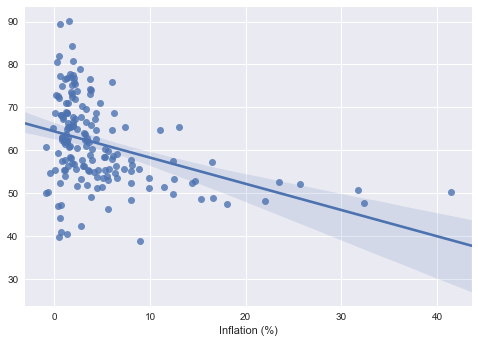

```python
%matplotlib inline
plt.style.use('seaborn')
sns.regplot(x2,y)
```

#### With that question answered, let's see which region of the world has the highest economic freedom on average

```python
Region_Score=df['2019 Score'].groupby([df['Region']]).mean()
Region_Score
```

```
Region
Americas                        60.526667
Asia-Pacific                    62.555000
Europe                          68.665116
Middle East and North Africa    61.257143
Sub-Saharan Africa              54.026087
Name: 2019 Score, dtype: float64
```

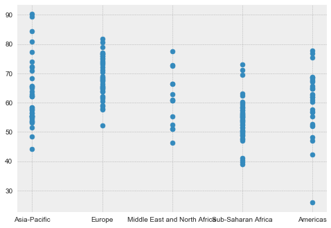

```python
plt.style.use('bmh')
plt.scatter('Region', '2019 Score', data=df)
```

Based on the data, Europe is the region with the highest amount of economic freedom and has the narrowest variation in that regard. Interestingly, the Americas have a lower economic freedom score on average than both Asia-Pacific and the Middle East and North African regions. Also Sub-Saharan Africa comes in dead last for economic freedom, only have about 79% of the economic freedom of an average european country.

## Comparing the annual FDI and the Percentage Tariff and Corporate Tax Rates to the Unemployment Rate

```python
x4 = df[['FDI Inflow (Millions)']+['Tariff Rate (%)']+['Corporate Tax Rate (%)']]
y2=df['Unemployment (%)'].values
x5= sm.add_constant(x4)
reg4= sm.OLS(y2,x5, missing='drop')
results3 = reg4.fit()
print(results3.summary())
```

```
                            OLS Regression Results
==============================================================================
Dep. Variable:                      y   R-squared:                       0.012
Model:                            OLS   Adj. R-squared:                 -0.006
Method:                 Least Squares   F-statistic:                    0.6659
Date:                Tue, 08 Oct 2019   Prob (F-statistic):              0.574
Time:                        16:25:23   Log-Likelihood:                -544.40
No. Observations:                 173   AIC:                             1097.
Df Residuals:                     169   BIC:                             1109.
Df Model:                           3
Covariance Type:            nonrobust
==========================================================================================
                             coef    std err          t      P>|t|      [0.025      0.975]
------------------------------------------------------------------------------------------
const                      6.9560      1.281      5.430      0.000       4.427       9.485
FDI Inflow (Millions)  -2.166e-05   1.67e-05     -1.295      0.197   -5.47e-05    1.14e-05
Tariff Rate (%)           -0.0340      0.106     -0.321      0.748      -0.243       0.175
Corporate Tax Rate (%)     0.0312      0.051      0.607      0.544      -0.070       0.133
==============================================================================
Omnibus:                       56.552   Durbin-Watson:                   1.831
Prob(Omnibus):                  0.000   Jarque-Bera (JB):              111.358
Skew:                           1.558   Prob(JB):                     6.59e-25
Kurtosis:                       5.395   Cond. No.                     8.20e+04
==============================================================================

Warnings:
[1] Standard Errors assume that the covariance matrix of the errors is correctly specified.
[2] The condition number is large, 8.2e+04. This might indicate that there are
strong multicollinearity or other numerical problems.
```

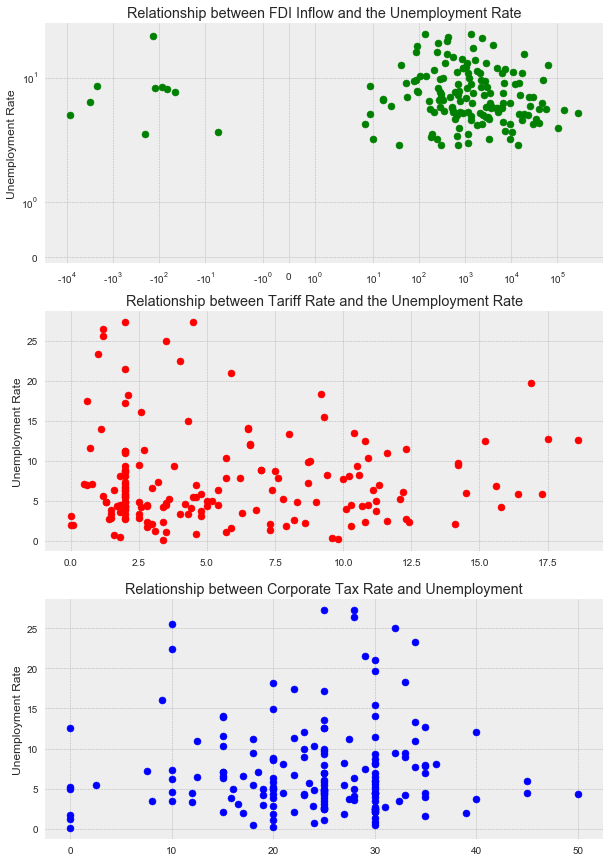

```python
fig, (ax1, ax2, ax3) = plt.subplots(figsize=(10,15), nrows=3, ncols=1)
ax1.scatter(df['FDI Inflow (Millions)'],y2, c='g')
ax1.set_title('Relationship between FDI Inflow and the Unemployment Rate')
ax1.set_ylabel('Unemployment Rate')
ax1.set_xscale('symlog')
ax1.set_yscale('symlog')
ax2.scatter(df['Tariff Rate (%)'],y2, c='red')
ax2.set_title('Relationship between Tariff Rate and the Unemployment Rate')
ax2.set_ylabel('Unemployment Rate')
ax3.scatter(df['Corporate Tax Rate (%)'],y2, c='blue')
ax3.set_title('Relationship between Corporate Tax Rate and Unemployment')
ax3.set_ylabel('Unemployment Rate')
```

These scatterplots are meant to show the relationship between the unemployment rate and the three variables run in the regression. As the FDI scatterplot had an extreme outlier in it, I decided to run the logged version of their relationship to better visualize it. These charts also show next to no relationship between the three x variables and the unemployment rate, agreeing with the findings of the regression analysis run above.

## Determining the Probability of a Country being in the Top 10% of Countries Ranked on the Index Based on their Government Integrity, Tax Burden, and Public Debt

```python
# Step 1: Create a new binary variable to determine which countries are in the top 10%.
df['Top 10%'] = np.where(df['World Rank']<=18, 1, 0)
df.head()
```

| CountryID | Country Name | Region | World Rank | Region Rank | 2019 Score | Property Rights | Judical Effectiveness | Government Integrity | Tax Burden | Gov't Spending | ... | Population (Millions) | GDP (Billions, PPP) | GDP Growth Rate (%) | 5 Year GDP Growth Rate (%) | GDP per Capita (PPP) | Unemployment (%) | Inflation (%) | FDI Inflow (Millions) | Public Debt (% of GDP) | Top 10% |
| --- | --- | --- | --- | --- | --- | --- | --- | --- | --- | --- | --- | --- | --- | --- | --- | --- | --- | --- | --- | --- | --- |
| 1.0 | Afghanistan | Asia-Pacific | 152.0 | 39.0 | 51.5 | 19.6 | 29.6 | 25.2 | 91.7 | 80.3 | ... | 35.5 | 69.6 | 2.5 | 2.9 | 1958.0 | 8.8 | 5.0 | 53.9 | 7.3 | 0 |
| 2.0 | Albania | Europe | 52.0 | 27.0 | 66.5 | 54.8 | 30.6 | 40.4 | 86.3 | 73.9 | ... | 2.9 | 36.0 | 3.9 | 2.5 | 12507.0 | 13.9 | 2.0 | 1119.1 | 71.2 | 0 |
| 3.0 | Algeria | Middle East and North Africa | 171.0 | 14.0 | 46.2 | 31.6 | 36.2 | 28.9 | 76.4 | 48.7 | ... | 41.5 | 632.9 | 2.0 | 3.1 | 15237.0 | 10.0 | 5.6 | 1203.0 | 25.8 | 0 |
| 4.0 | Angola | Sub-Saharan Africa | 156.0 | 33.0 | 50.6 | 35.9 | 26.6 | 20.5 | 83.9 | 80.7 | ... | 28.2 | 190.3 | 0.7 | 2.9 | 6753.0 | 8.2 | 31.7 | -2254.5 | 65.3 | 0 |
| 5.0 | Argentina | Americas | 148.0 | 26.0 | 52.2 | 47.8 | 44.5 | 33.5 | 69.3 | 49.5 | ... | 44.1 | 920.2 | 2.9 | 0.7 | 20876.0 | 8.7 | 25.7 | 11857.0 | 52.6 | 0 |

5 rows × 32 columns

```python
#Define new x and y, add a constant, and run the logistical regression
x5 = df[['Government Integrity']+['Tax Burden']+['Public Debt (% of GDP)']]
y3=df['Top 10%'].values
x6= sm.add_constant(x5)
logit1 = sm.Logit(y3, x6, missing='drop')
results4 = logit1.fit().params
results4
```

```
Optimization terminated successfully.
         Current function value: 0.116421
         Iterations 9
```

```
const                    -14.611586
Government Integrity       0.153614
Tax Burden                 0.055177
Public Debt (% of GDP)    -0.019435
dtype: float64
```

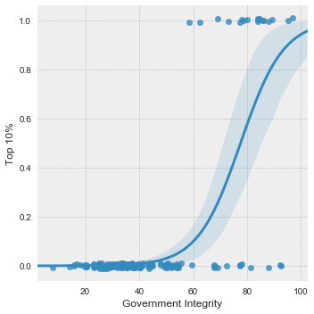

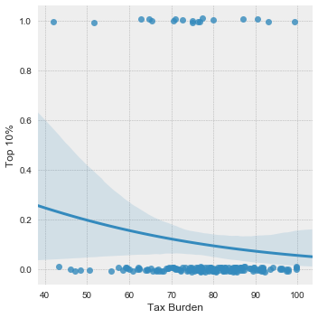

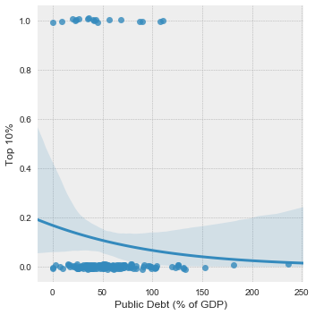

```python
#Plot the individual curves
plt.style.use('bmh')
sns.lmplot(x= 'Government Integrity', y= 'Top 10%', data=df, logistic=True, y_jitter=.01)
sns.lmplot(x= 'Tax Burden', y= 'Top 10%', data=df, logistic=True, y_jitter=.01)
sns.lmplot(x= 'Public Debt (% of GDP)', logistic=True, y= 'Top 10%', data=df, y_jitter=.01)
```

## Determining the Relationship Between all the Relevant Independent Variable's and a Country's Economic Freedom Score in 2019

##### Null hypothesis: There is no statistically significant relationship between any of the independent variables and a country's Economic Freedom Score in 2019

##### Alternative hypothesis: There is a statistically significant relationship between at least one of the indepedent variables and a country's Economic Freedom Score in 2019

```python
x7= df.drop(['Country Name', 'World Rank', 'Region Rank', 'Region', '2019 Score', 'Top 10%'], axis=1)
x8=sm.add_constant(x7)
y4= df['2019 Score']
reg5= sm.OLS(y4,x8, missing='drop')
results4 = reg5.fit()
print(results4.summary())
```

```
                            OLS Regression Results
==============================================================================
Dep. Variable:             2019 Score   R-squared:                       1.000
Model:                            OLS   Adj. R-squared:                  1.000
Method:                 Least Squares   F-statistic:                 7.959e+05
Date:                Tue, 08 Oct 2019   Prob (F-statistic):               0.00
Time:                        16:25:32   Log-Likelihood:                 377.76
No. Observations:                 173   AIC:                            -701.5
Df Residuals:                     146   BIC:                            -616.4
Df Model:                          26
Covariance Type:            nonrobust
===============================================================================================
                                  coef    std err          t      P>|t|      [0.025      0.975]
-----------------------------------------------------------------------------------------------
const                          -0.1762      0.136     -1.294      0.198      -0.445       0.093
Property Rights                 0.0837      0.000    241.492      0.000       0.083       0.084
Judical Effectiveness           0.0829      0.000    254.347      0.000       0.082       0.083
Government Integrity            0.0835      0.000    244.844      0.000       0.083       0.084
Tax Burden                      0.0832      0.001     92.432      0.000       0.081       0.085
Gov't Spending                  0.0847      0.001    119.017      0.000       0.083       0.086
Fiscal Health                   0.0833   9.75e-05    855.023      0.000       0.083       0.084
Business Freedom                0.0834      0.000    296.442      0.000       0.083       0.084
Labor Freedom                   0.0834      0.000    405.443      0.000       0.083       0.084
Monetary Freedom                0.0826      0.000    199.226      0.000       0.082       0.083
Trade Freedom                   0.0842      0.001     78.831      0.000       0.082       0.086
Investment Freedom              0.0831      0.000    382.797      0.000       0.083       0.084
Financial Freedom               0.0834      0.000    342.426      0.000       0.083       0.084
Tariff Rate (%)                 0.0022      0.002      0.993      0.322      -0.002       0.006
Income Tax Rate (%)             0.0003      0.001      0.600      0.550      -0.001       0.001
Corporate Tax Rate (%)         -0.0005      0.000     -0.961      0.338      -0.001       0.001
Tax Burden % of GDP            -0.0003      0.001     -0.539      0.591      -0.001       0.001
Gov't Expenditure % of GDP      0.0028      0.001      1.852      0.066      -0.000       0.006
Population (Millions)        4.829e-05   3.37e-05      1.435      0.153   -1.82e-05       0.000
GDP (Billions, PPP)         -1.879e-06   3.04e-06     -0.617      0.538   -7.89e-06    4.14e-06
GDP Growth Rate (%)             0.0011      0.002      0.691      0.490      -0.002       0.004
5 Year GDP Growth Rate (%)     -0.0030      0.002     -1.868      0.064      -0.006       0.000
GDP per Capita (PPP)         8.078e-09   1.81e-07      0.045      0.964    -3.5e-07    3.66e-07
Unemployment (%)               -0.0001      0.001     -0.291      0.772      -0.001       0.001
Inflation (%)               -7.811e-05   4.41e-05     -1.769      0.079      -0.000    9.14e-06
FDI Inflow (Millions)        -1.11e-07   1.93e-07     -0.574      0.567   -4.93e-07    2.71e-07
Public Debt (% of GDP)      -2.608e-05   7.99e-05     -0.326      0.745      -0.000       0.000
==============================================================================
Omnibus:                       22.524   Durbin-Watson:                   2.062
Prob(Omnibus):                  0.000   Jarque-Bera (JB):                6.492
Skew:                           0.018   Prob(JB):                       0.0389
Kurtosis:                       2.052   Cond. No.                     2.12e+06
==============================================================================

Warnings:
[1] Standard Errors assume that the covariance matrix of the errors is correctly specified.
[2] The condition number is large, 2.12e+06. This might indicate that there are
strong multicollinearity or other numerical problems.
```

While the model proved to be statistically significant, many of the variables within the model proved not to be so. Ironically, it was mostly the semi-arbitary numbers that proved to have a statisticaly significant relationship with the 2019 score. These numbers are the ones created by the Heritage Foundation, like a country's trade freedom, labor freedom, and business freedom. The hard data like the income tax rate, corporate tax rate, and GDP per capita were all deemed stastically insignificant. In terms of accounting for the noise and variation in the data though, this model is perfect, getting an R-squared value of 1.0.

The null hypothesis is therefore rejected and the alternative is not rejected.

Granted, with all the statistically insignificant independent variables, this model could be made better, so I'm going to clean it up a bit.

```python
# While I remove all the insignicant columns in two steps here, I did check the columns independently to make sure they were still statistically insignificant when I removed the columns with the highest p-value.
x9=x7.drop(['Public Debt (% of GDP)', 'GDP per Capita (PPP)', 'GDP (Billions, PPP)', 'Income Tax Rate (%)', 'Unemployment (%)', 'GDP Growth Rate (%)', 'Population (Millions)', '5 Year GDP Growth Rate (%)','FDI Inflow (Millions)', 'Tariff Rate (%)', 'Corporate Tax Rate (%)', 'Inflation (%)', 'Tax Burden % of GDP'], axis=1)
x10=x9.drop(x9.columns[-1], axis=1)
reg6= sm.OLS(y4,x10, missing='drop')
results5 = reg6.fit()
print(results5.summary())
```

```
                                 OLS Regression Results
=======================================================================================
Dep. Variable:             2019 Score   R-squared (uncentered):                   1.000
Model:                            OLS   Adj. R-squared (uncentered):              1.000
Method:                 Least Squares   F-statistic:                          6.281e+07
Date:                Tue, 08 Oct 2019   Prob (F-statistic):                        0.00
Time:                        16:25:32   Log-Likelihood:                          368.53
No. Observations:                 173   AIC:                                     -713.1
Df Residuals:                     161   BIC:                                     -675.2
Df Model:                          12
Covariance Type:            nonrobust
=========================================================================================
                            coef    std err          t      P>|t|      [0.025      0.975]
-----------------------------------------------------------------------------------------
Property Rights           0.0839      0.000    264.953      0.000       0.083       0.085
Judical Effectiveness     0.0830      0.000    275.929      0.000       0.082       0.084
Government Integrity      0.0834      0.000    276.249      0.000       0.083       0.084
Tax Burden                0.0834      0.000    386.078      0.000       0.083       0.084
Gov't Spending            0.0835      0.000    640.019      0.000       0.083       0.084
Fiscal Health             0.0833   8.16e-05   1021.185      0.000       0.083       0.083
Business Freedom          0.0835      0.000    313.313      0.000       0.083       0.084
Labor Freedom             0.0833      0.000    428.468      0.000       0.083       0.084
Monetary Freedom          0.0832      0.000    334.596      0.000       0.083       0.084
Trade Freedom             0.0832      0.000    291.820      0.000       0.083       0.084
Investment Freedom        0.0831      0.000    417.845      0.000       0.083       0.083
Financial Freedom         0.0833      0.000    357.751      0.000       0.083       0.084
==============================================================================
Omnibus:                       54.558   Durbin-Watson:                   2.026
Prob(Omnibus):                  0.000   Jarque-Bera (JB):                9.379
Skew:                          -0.036   Prob(JB):                      0.00919
Kurtosis:                       1.862   Cond. No.                         37.8
==============================================================================

Warnings:
[1] Standard Errors assume that the covariance matrix of the errors is correctly specified.
```

This model is a lot better and all the independent variables in it are statistically significant. The AIC for the model has also improved over the AIC for the last matter, which is a good sign. The final model concludes that each single point increase in any of the indicators created by the Heritage Foundation will increase a country's Economic Freedom Score by about .083 points with no statistically significant constant.

## Principle Component Analysis for Several of the Above Indicators by Regions

```python
features = ['Property Rights', 'Judical Effectiveness', 'Government Integrity', 'Tax Burden']
x11 = df.loc[:, features].values
y5 = df.loc[:,['Region']].values
x11 = StandardScaler().fit_transform(x11)
#Standardizing the data to make sure change in variance due to scaling differences doesn't effect future PCA
```

```python
pca = PCA(n_components=2)
principalComponents = pca.fit_transform(x11)
df3 = pd.DataFrame(data = principalComponents,columns = ['principal component 1', 'principal component 2'])
pcadf = pd.concat([df3, df[['Region']]], axis=1)
```

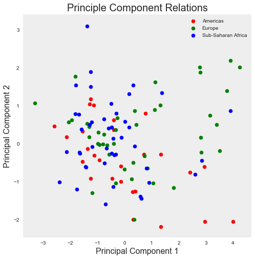

```python
fig = plt.figure(figsize = (8,8))
ax = fig.add_subplot(1,1,1)
ax.set_xlabel('Principal Component 1', fontsize = 16)
ax.set_ylabel('Principal Component 2', fontsize = 16)
ax.set_title('Principle Component Relations', fontsize = 20)
targets = ['Americas', 'Europe', 'Sub-Saharan Africa']
colors = ['r', 'g', 'b']
for region, color in zip(targets,colors):
    indicesToKeep = pcadf['Region'] == region
    ax.scatter(pcadf.loc[indicesToKeep, 'principal component 1']
               , pcadf.loc[indicesToKeep, 'principal component 2']
               , c = color
               , s = 50)
ax.legend(targets)

ax.grid()
```

```python
pca.explained_variance_ratio_
```

```
array([0.70661743, 0.22440948])
```

### Results:

As the chart shows and information below it show, the first principle component accounts for 71% of the total variation in the data, and the second principle component accounts for another 22%. In total the two principle components accounts for 93% of the total variation in the data.

## Linear Discriminant Analysis

```python
#resusing the data for x and y in the PCA scenario for LDA
x11
y5
lda = LDA(n_components=2)
x11 = lda.fit_transform(x11,y5)
```

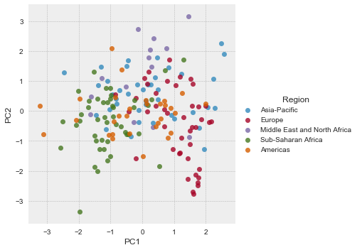

```python
df['PC1'] = x11[:,0]
df['PC2'] = x11[:,1]
ldaplot = sns.lmplot(data = df[['PC1','PC2','Region']], x = 'PC1', y = 'PC2',fit_reg=False, hue = 'Region')
```

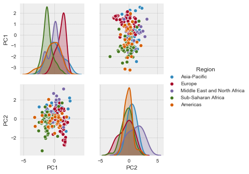

```python
sns.pairplot(df[['PC1','PC2', 'Region']], hue='Region')
```

```python
lda.explained_variance_ratio_
```

```
array([0.67801663, 0.28843713])
```